# 张嘉辰_2018201743_统计软件第5次作业

张嘉辰

2020年11月24日

# 任务一

```r
#读入数据
chexian <- read.csv("D:/data/chexian.csv", header = TRUE)
#查看数据
summary(chexian)
```

```
##     EngSize           Age        Gender    Marital          exp
##  Min.   :1.000   Min.   :21.00   男:3775   未婚: 205   Min.   : 0.000
##  1st Qu.:1.600   1st Qu.:33.00   女: 458   已婚:4028   1st Qu.: 3.000
##  Median :1.800   Median :38.00                         Median : 5.000
##  Mean   :1.815   Mean   :38.18                         Mean   : 5.954
##  3rd Qu.:1.800   3rd Qu.:42.00                         3rd Qu.: 8.000
##  Max.   :3.000   Max.   :66.00                         Max.   :20.000
##   Owner      Garage          AntiTFD      import       LossClass
##  公司: 869   无: 687   无防盗装置:3285   国产:2970   Min.   :0.0000
##  私人:3027   有:3546   有防盗装置: 948   进口:1263   1st Qu.:0.0000
##  政府: 337                                           Median :0.0000
##                                                      Mean   :0.2847
##                                                      3rd Qu.:1.0000
##                                                      Max.   :1.0000
##  vAgeNew
##  旧车:1964
##  新车:2269
##
##
##
##
```

# 任务二

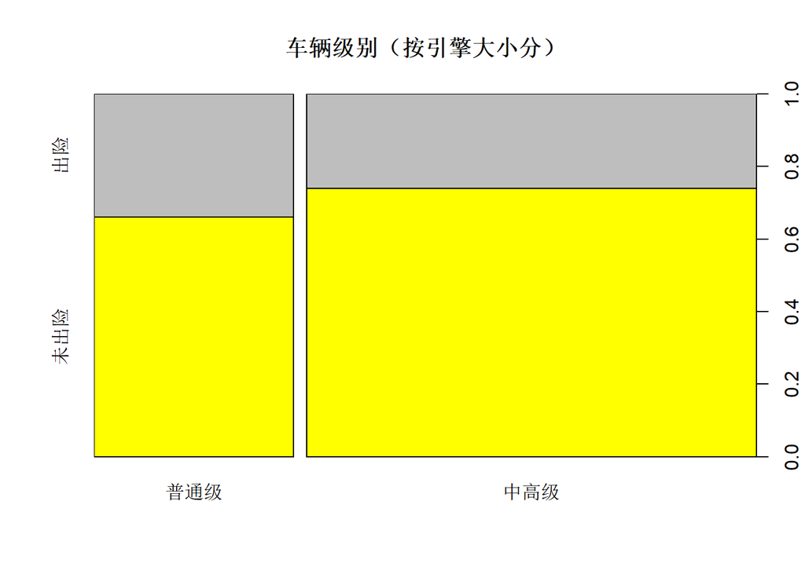

```r
#离散化
#将离散化后的发动机引擎级别作为新的变量加入数据框chexian中
chexian$EngLevel <- cut(chexian$EngSize, breaks = c(0.99, 1.6, 3.11), labels = c("普通级", "中高级"))
#将是否出现变量转化为因子类型，且将两个水平命名为“未出险”和“出险”
chexian$LossClass_fac <- factor(chexian$LossClass, levels = c(0, 1), labels = c("未出险", "出险"))
#画出棘状图
spineplot(x = chexian$EngLevel, y = chexian$LossClass_fac, xlab = "", ylab = "", main = "车辆级别（按引擎大小分）", col = c(7,8))
```

从图中看到，普通级车辆出险率更高。可以初步判断和车辆级别会影响出险行为，且普通的车辆更可能出险。

棘状图中柱子的宽度代表样本量的大小。可以看到，中高级车辆的样本量比普通级的更大。

# 任务三

```r
#全模型
logi_Full <- glm(LossClass_fac~EngLevel+AntiTFD+Garage+import+Owner+Age+exp+Gender+Marital+vAgeNew, data = chexian, family = binomial(link = logit))
summary(logi_Full)
```

```
##
## Call:
## glm(formula = LossClass_fac ~ EngLevel + AntiTFD + Garage + import +
##     Owner + Age + exp + Gender + Marital + vAgeNew, family = binomial(link = logit),
##     data = chexian)
##
## Deviance Residuals:
##     Min       1Q   Median       3Q      Max
## -1.1814  -0.8697  -0.7182   1.3435   2.2132
##
## Coefficients:
##                    Estimate Std. Error z value Pr(>|z|)
## (Intercept)       -1.173153   0.248804  -4.715 2.42e-06 ***
## EngLevel中高级    -0.309812   0.078254  -3.959 7.52e-05 ***
## AntiTFD有防盗装置  0.086486   0.083751   1.033 0.301761
## Garage有           0.222173   0.100627   2.208 0.027252 *
## import进口         0.149224   0.080492   1.854 0.063754 .
## Owner私人          0.355575   0.099111   3.588 0.000334 ***
## Owner政府         -0.337561   0.179268  -1.883 0.059701 .
## Age               -0.003869   0.005135  -0.754 0.451137
## exp               -0.027420   0.009007  -3.044 0.002332 **
## Gender女           0.168812   0.107316   1.573 0.115711
## Marital已婚        0.043742   0.166253   0.263 0.792469
## vAgeNew新车        0.359426   0.075408   4.766 1.88e-06 ***
## ---
## Signif. codes:  0 '***' 0.001 '**' 0.01 '*' 0.05 '.' 0.1 ' ' 1
##
## (Dispersion parameter for binomial family taken to be 1)
##
##     Null deviance: 5056.8  on 4232  degrees of freedom
## Residual deviance: 4892.4  on 4221  degrees of freedom
## AIC: 4916.4
##
## Number of Fisher Scoring iterations: 4
```

```r
#AIC模型
logi_AIC <- step(logi_Full, k = 2)
```

```
## Start:  AIC=4916.45
## LossClass_fac ~ EngLevel + AntiTFD + Garage + import + Owner +
##     Age + exp + Gender + Marital + vAgeNew
##
##            Df Deviance    AIC
## - Marital   1   4892.5 4914.5
## - Age       1   4893.0 4915.0
## - AntiTFD   1   4893.5 4915.5
## <none>          4892.4 4916.4
## - Gender    1   4894.9 4916.9
## - import    1   4895.9 4917.9
## - Garage    1   4897.4 4919.4
## - exp       1   4901.9 4923.9
## - EngLevel  1   4908.0 4930.0
## - vAgeNew   1   4915.3 4937.3
## - Owner     2   4918.5 4938.5
##
## Step:  AIC=4914.52
## LossClass_fac ~ EngLevel + AntiTFD + Garage + import + Owner +
##     Age + exp + Gender + vAgeNew
##
##            Df Deviance    AIC
## - Age       1   4893.0 4913.0
## - AntiTFD   1   4893.6 4913.6
## <none>          4892.5 4914.5
## - Gender    1   4895.0 4915.0
## - import    1   4895.9 4915.9
## - Garage    1   4897.5 4917.5
## - exp       1   4901.9 4921.9
## - EngLevel  1   4908.1 4928.1
## - vAgeNew   1   4915.4 4935.4
## - Owner     2   4918.6 4936.6
##
## Step:  AIC=4913.02
## LossClass_fac ~ EngLevel + AntiTFD + Garage + import + Owner +
##     exp + Gender + vAgeNew
##
##            Df Deviance    AIC
## - AntiTFD   1   4894.1 4912.1
## <none>          4893.0 4913.0
## - Gender    1   4895.6 4913.6
## - import    1   4896.5 4914.5
## - Garage    1   4898.0 4916.0
## - exp       1   4903.8 4921.8
## - EngLevel  1   4908.7 4926.7
## - vAgeNew   1   4915.9 4933.9
## - Owner     2   4918.6 4934.6
##
## Step:  AIC=4912.08
## LossClass_fac ~ EngLevel + Garage + import + Owner + exp + Gender +
##     vAgeNew
##
##            Df Deviance    AIC
## <none>          4894.1 4912.1
## - Gender    1   4896.7 4912.7
## - import    1   4897.9 4913.9
## - Garage    1   4898.7 4914.7
## - exp       1   4904.8 4920.8
## - EngLevel  1   4909.2 4925.2
## - vAgeNew   1   4917.7 4933.7
## - Owner     2   4920.0 4934.0
```

```r
#AIC模型的估计结果
summary(logi_AIC)
```

```
##
## Call:
## glm(formula = LossClass_fac ~ EngLevel + Garage + import + Owner +
##     exp + Gender + vAgeNew, family = binomial(link = logit),
##     data = chexian)
##
## Deviance Residuals:
##     Min       1Q   Median       3Q      Max
## -1.1809  -0.8722  -0.7192   1.3431   2.2068
##
## Coefficients:
##                 Estimate Std. Error z value Pr(>|z|)
## (Intercept)    -1.251625   0.147891  -8.463  < 2e-16 ***
## EngLevel中高级 -0.303636   0.077932  -3.896 9.77e-05 ***
## Garage有        0.212103   0.100166   2.118 0.034216 *
## import进口      0.157924   0.080080   1.972 0.048601 *
## Owner私人       0.350529   0.098778   3.549 0.000387 ***
## Owner政府      -0.332505   0.178676  -1.861 0.062753 .
## exp            -0.028469   0.008786  -3.240 0.001194 **
## Gender女        0.174848   0.106984   1.634 0.102187
## vAgeNew新车     0.364439   0.075219   4.845 1.27e-06 ***
## ---
## Signif. codes:  0 '***' 0.001 '**' 0.01 '*' 0.05 '.' 0.1 ' ' 1
##
## (Dispersion parameter for binomial family taken to be 1)
##
##     Null deviance: 5056.8  on 4232  degrees of freedom
## Residual deviance: 4894.1  on 4224  degrees of freedom
## AIC: 4912.1
##
## Number of Fisher Scoring iterations: 4
```

```r
#BIC模型
logi_BIC <- step(logi_Full, k = log(nrow(chexian)))
```

```
## Start:  AIC=4992.66
## LossClass_fac ~ EngLevel + AntiTFD + Garage + import + Owner +
##     Age + exp + Gender + Marital + vAgeNew
##
##            Df Deviance    AIC
## - Marital   1   4892.5 4984.4
## - Age       1   4893.0 4984.9
## - AntiTFD   1   4893.5 4985.4
## - Gender    1   4894.9 4986.8
## - import    1   4895.9 4987.7
## - Garage    1   4897.4 4989.3
## <none>          4892.4 4992.7
## - exp       1   4901.9 4993.8
## - EngLevel  1   4908.0 4999.9
## - Owner     2   4918.5 5002.0
## - vAgeNew   1   4915.3 5007.2
##
## Step:  AIC=4984.38
## LossClass_fac ~ EngLevel + AntiTFD + Garage + import + Owner +
##     Age + exp + Gender + vAgeNew
##
##            Df Deviance    AIC
## - Age       1   4893.0 4976.5
## - AntiTFD   1   4893.6 4977.1
## - Gender    1   4895.0 4978.5
## - import    1   4895.9 4979.5
## - Garage    1   4897.5 4981.0
## <none>          4892.5 4984.4
## - exp       1   4901.9 4985.4
## - EngLevel  1   4908.1 4991.6
## - Owner     2   4918.6 4993.8
## - vAgeNew   1   4915.4 4998.9
##
## Step:  AIC=4976.53
## LossClass_fac ~ EngLevel + AntiTFD + Garage + import + Owner +
##     exp + Gender + vAgeNew
##
##            Df Deviance    AIC
## - AntiTFD   1   4894.1 4969.2
## - Gender    1   4895.6 4970.8
```

[output cut: 39 more lines]

```
## <none>          4901.1 4959.6
## - exp       1   4912.8 4962.9
## - EngLevel  1   4913.5 4963.7
## - Owner     2   4928.1 4969.9
## - vAgeNew   1   4929.8 4979.9
##
## Step:  AIC=4955.98
## LossClass_fac ~ EngLevel + Owner + exp + vAgeNew
##
##            Df Deviance    AIC
## <none>          4905.9 4956.0
## - exp       1   4917.1 4958.9
## - EngLevel  1   4918.2 4960.0
## - Owner     2   4934.3 4967.7
## - vAgeNew   1   4936.8 4978.5
```

```r
#BIC模型的估计结果
summary(logi_BIC)
```

```
##
## Call:
## glm(formula = LossClass_fac ~ EngLevel + Owner + exp + vAgeNew,
##     family = binomial(link = logit), data = chexian)
##
## Deviance Residuals:
##     Min       1Q   Median       3Q      Max
## -1.0568  -0.8821  -0.7282   1.3414   2.1322
##
## Coefficients:
##                 Estimate Std. Error z value Pr(>|z|)
## (Intercept)    -1.064911   0.125458  -8.488  < 2e-16 ***
## EngLevel中高级 -0.260700   0.073836  -3.531 0.000414 ***
## Owner私人       0.365761   0.098431   3.716 0.000202 ***
## Owner政府      -0.345977   0.178454  -1.939 0.052533 .
## exp            -0.028999   0.008739  -3.318 0.000906 ***
## vAgeNew新车     0.408637   0.073899   5.530 3.21e-08 ***
## ---
## Signif. codes:  0 '***' 0.001 '**' 0.01 '*' 0.05 '.' 0.1 ' ' 1
##
## (Dispersion parameter for binomial family taken to be 1)
##
##     Null deviance: 5056.8  on 4232  degrees of freedom
## Residual deviance: 4905.9  on 4227  degrees of freedom
## AIC: 4917.9
##
## Number of Fisher Scoring iterations: 4
```

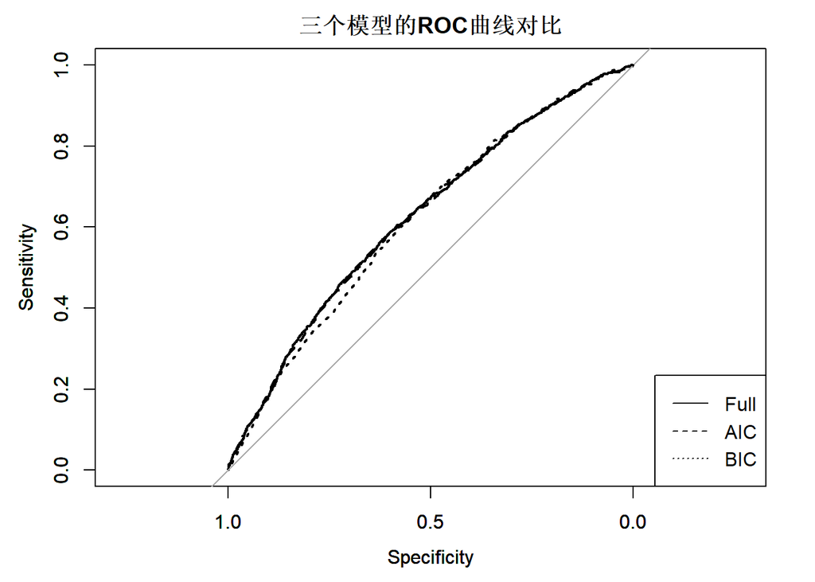

```r
#ROC曲线
library(pROC)
#使用全模型进行预测
#第2至9列和第11至12列是自变量
pred_Full <- predict(logi_Full, newdata = chexian[, c(2:9, 11:12)], type = "response")
#全模型的ROC曲线
roc_Full <- roc(chexian$LossClass ~ pred_Full, plot = FALSE, print.auc = FALSE)

#使用AIC模型进行预测
pred_AIC <- predict(logi_AIC, newdata = chexian[, c(2:9, 11:12)], type = "response")
#AIC模型的ROC曲线
roc_AIC <- roc(chexian$LossClass ~ pred_AIC, plot = FALSE, print.auc = FALSE)

#使用BIC模型进行预测
pred_BIC <- predict(logi_BIC, newdata = chexian[, c(2:9, 11:12)], type = "response")
#BIC模型的ROC曲线
roc_BIC <- roc(chexian$LossClass ~ pred_BIC, plot = FALSE, print.auc = FALSE)

#把三个模型的ROC曲线画在一张图上
plot(roc_Full, main = "三个模型的ROC曲线对比")
par(new = TRUE)
#通过线形区分三个模型的ROC曲线
plot(roc_AIC, lty = 2)
par(new = TRUE)
plot(roc_BIC, lty = 3)
#添加图例
legend("bottomright",  c("Full", "AIC", "BIC"),
       lty=c(1, 2, 3))
```

```r
#auc值保留四位小数
auc_df <- data.frame(round(c(roc_Full$auc, roc_AIC$auc, roc_BIC$auc),4))
row.names(auc_df) <- c("全模型", "AIC模型", "BIC模型")
colnames(auc_df) <- c("auc")
knitr::kable(auc_df, format = "html")
```

|  | auc |
| --- | --- |
| 全模型 | 0.6253 |
| AIC模型 | 0.6241 |
| BIC模型 | 0.6177 |

全模型包括的自变量有10个：驾驶人年龄（Age）、驾驶人驾龄（exp）、驾驶人性别（Gender）、驾驶人婚姻状况（Marital）、汽车车龄（vAgeNew）、发动机引擎大小（EngSize）、是否进口（import）、所有者性质（owner）、固定车位（Garage）、防盗装置（AntiTFD）

AIC模型包括的自变量有7个：驾驶人驾龄（exp）、驾驶人性别（Gender）、汽车车龄（vAgeNew）、发动机引擎大小（EngSize）、是否进口（import）、所有者性质（owner）、固定车位（Garage）

BIC模型包括的自变量有4个：驾驶人驾龄（exp）、汽车车龄（vAgeNew）、发动机引擎大小（EngSize）、所有者性质（owner）

AUC值反映了模型的预测精度，通常认为AUC值较大的模型预测精度更高。

可以看到，BIC模型的AUC值最小，而全模型和AIC模型的AUC值接近。因此，在保证模型精度较高的前提下，根据简洁性原则，选择AIC模型。

# 任务四

选择AIC模型。

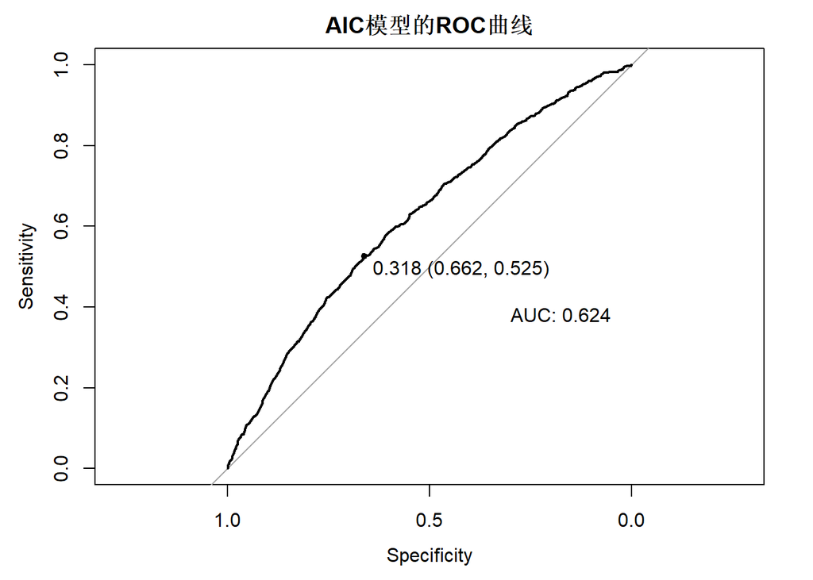

```r
#最佳阈值
thre_AIC <- as.numeric(coords(roc_AIC, "best", ret="threshold", transpose = FALSE))

#画出AIC模型的ROC曲线，在图中显示最佳阈值和AUC值
#参数print.auc.x和print.auc.y用于调整图中AUC值的显示位置
plot(roc_AIC, print.thres="best", print.auc = TRUE, print.auc.x = 0.3,  print.auc.y = 0.4, main = "AIC模型的ROC曲线")

library(caret)
```

```r
#构建混淆矩阵
#positive定义为出险
conf_matr <- t(confusionMatrix(data = factor(as.integer(pred_AIC>thre_AIC), levels = c(0,1), labels = c("未出险", "出险")), reference = chexian[,13], dnn = c("预测值", "真实值"), positive='出险')$table)
#在混淆矩阵中添加行和与列和
conf_matr <- addmargins(conf_matr)
knitr::kable(conf_matr, format = "html")
```

|  | 未出险 | 出险 | Sum |
| --- | --- | --- | --- |
| 未出险 | 2004 | 1024 | 3028 |
| 出险 | 572 | 633 | 1205 |
| Sum | 2576 | 1657 | 4233 |

$AUC=0.624>0.5$，说明模型较好；

最佳阈值为0.318，此时的灵敏度和特异度均较高。

可以从混淆矩阵中计算得到，

整体错判率为$\frac{(1024+572)}{4233}=37.7%$

抓住坏蛋的概率$TPR=\frac{633}{1205}=52.5%>50%$

模型的灵敏度$Sensitivity=TPR=52.5%>50%$

模型的特异度$Specificity=1-FPR=66.2%>50%$

说明模型的灵敏度和特异度均较好。

# 任务五

```r
#在chexian数据框中添加AIC模型预测的出险概率
chexian$pred_AIC <- pred_AIC
#第14列是pred_AIC
#根据AIC模型预测的出险概率进行由高到低的排序
chexian <- chexian[order(-chexian[, 14]), ]
#将排序后的人群分为五等分
chexian_group <- split(chexian, rep(1:5, length.out = nrow(chexian), each = floor(nrow(chexian)/5)))
#每一组的人数
group_num <- sapply(chexian_group, nrow)
group_num
```

```
##   1   2   3   4   5
## 849 846 846 846 846
```

```r
#每一组实际出险的人数
group_loss <- sapply(chexian_group, function(x) sum(x$LossClass))
group_loss
```

```
##   1   2   3   4   5
## 361 276 225 199 144
```

```r
#每一组的实际出险概率
group_loss_prob <- group_loss/group_num
group_loss_prob
```

```
##         1         2         3         4         5
## 0.4252061 0.3262411 0.2659574 0.2352246 0.1702128
```

```r
#五组人群实际出现概率的平均值
mean(group_loss_prob)
```

```
## [1] 0.2845684
```

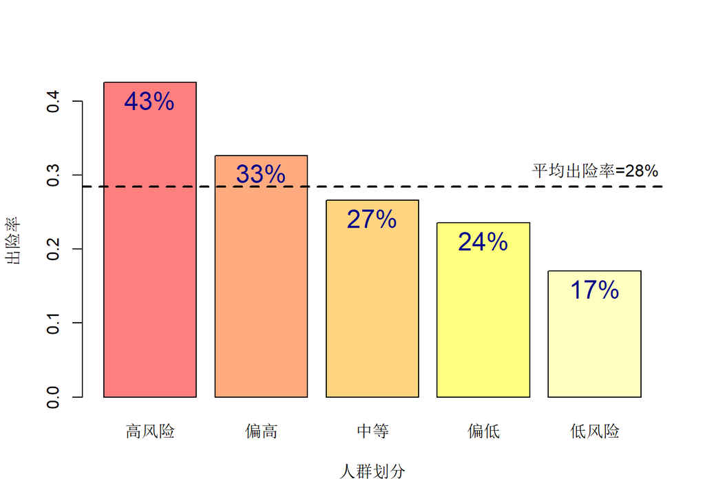

```r
#将每一组实际出险的概率转化为百分数
label_perc <- paste(100*round(group_loss_prob, 2), "%", sep = "")
##五种人群的标签
risk_name <- c("高风险", "偏高", "中等", "偏低", "低风险")
#画出五种人群实际出险率的柱状图，
plot_group <- barplot(height=group_loss_prob, names=risk_name, col = heat.colors(5, alpha = 0.5), xlab = "人群划分", ylab = "出险率")
#在每个柱子的上部添加实际出险率的百分数
text(x = plot_group, y = group_loss_prob, label = label_perc, pos = 1,  col = "darkblue", cex = 1.5)
#添加平均实际出险率的水平线
abline(h = mean(group_loss_prob), lty = 2, lwd = 2)
#添加平均出险率的文字
text(x = plot_group[5], y = mean(group_loss_prob), label = c("平均出险率=28%"), pos = 3)
```

从图中可以看到，占比20%的高风险人群的实际出险率达到43%，而占比60%的人群的实际出险率都低于平均值。

因此，可以根据影响出险的因素，来预测出险概率，区分高风险和低风险人群，从而制定基于驾驶行为的UBI车险产品。